# ISDS

https://www.buzzfeed.com/chrishamby/not-just-a-court-system-its-a-gold-mine

# Wikileaks Cables

[Cablegate](https://wikileaks.org/plusd/?qproject[]=ps&qproject[]=cg&qproject[]=cc&qproject[]=fp&qproject[]=ee&q=&qtfrom=1978-01-01&qtto=1978-12-31#result)

"The United States diplomatic cables leak, widely known as Cablegate, began on Sunday, 28 November 2010 when WikiLeaks—a non-profit organization that publishes submissions from anonymous whistleblowers—began releasing classified cables that had been sent to the U.S. State Department by 274 of its consulates, embassies, and diplomatic missions around the world. Dated between December 1966 and February 2010, the cables contain diplomatic analysis from world leaders, and the diplomats' assessment of host countries and their officials." ([wikipedia](https://en.wikipedia.org/wiki/United_States_diplomatic_cables_leak))

https://file.wikileaks.org/file/cablegate/

```python
"... " + records.iloc[0].text[2000:5000] + " ..."
```

```
'... of the Department of state 1964-66 Central Foreign Policy File File: POL 33-4 ARG --------------------------------------------- ----  E.O. 12958: DECL: DECLASSIFIED BY NARA 09/02/2009 TAGS: EFIS PBTS ARSUBJECT:  EXTENDED NATIONAL JURISDICTIONS OVER HIGH SEAS  REF: STATE 106206 CIRCULAR; STATE C…
```

```python
records.shape
```

```
(354885, 1)
```

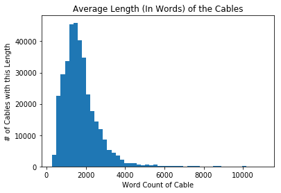

```python
lengths = records.text.apply(lambda x: len(x.split()))
lengths.hist(bins=50)
plt.grid()
plt.title('Average Length (In Words) of the Cables')
plt.ylabel('# of Cables with this Length')
plt.xlabel('Word Count of Cable');
```

Your editor slaps this pile of documents on your desk and says "We need you to go through these files to get a sense of whats going on, and to pick the interesting ones."

### Who wants to go through all these 300,000 records by hand?

# Let's see if there are computational techniques we can use to get a better picture of what's going on

# Approach #1: Look at words

## Word Counts

## total counts throughout corpus

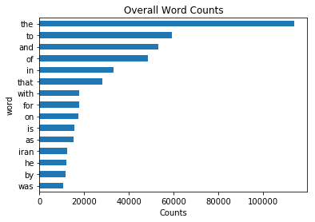

```python
plot_counts(vec, counts, title='Overall Word Counts')
```

## cut out the words that appear in nearly all of the documents

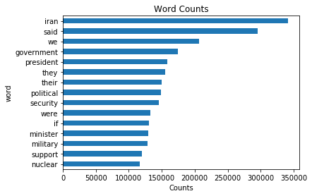

```python
plot_counts(vec, counts)
```

## Approach #1b. Go a bit deeper: Look at different types of words

# Part-of-Speech Tagging

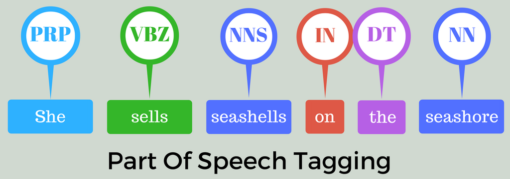

```python
Image('img/part_of_speech_tagging.png')
```

### Example bit of an annotated cable:

*1966/12/66BUENOSAIRES2481*

| no | DET |
| --- | --- |
| traditional | ADJ |
| fishing | NOUN |
| and | CCONJ |
| confine | PROPN |
| operative | PROPN |
| agreement | PROPN |
| to | ADP |
| provision | NOUN |
| for | ADP |
| non | PROPN |
| - | PUNCT |
| traditional | PROPN |
| fishing | NOUN |

### What are the most common verbs?

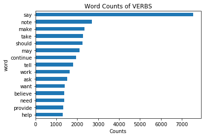

```python
verb_pipe = make_pipe('VERB')
verb_counts = verb_pipe.fit_transform(pos_tagging)
plot_counts(verb_pipe.named_steps['vec'], verb_counts, title='Word Counts of VERBS')
```

### Let's investigate the "help" verb. Who is helping? What is going on?

Options:

1. Search through all the documents with "help".
2. Get some more high-level views

Types of Part-of-speech available to look at:

ADJ ADP ADV CCONJ DET INTJ NOUN NUM PART PRON PROPN PUNCT SPACE SYM VERB

### Demo

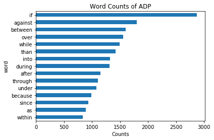

```python
verb_pipe = make_pipe('ADP')
verb_counts = verb_pipe.fit_transform(pos_tagging)
plot_counts(verb_pipe.named_steps['vec'], verb_counts, title='Word Counts of ADP')
```

### Proper Nouns

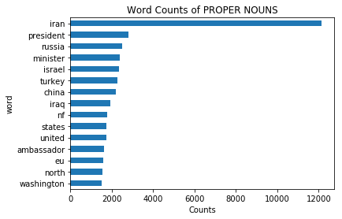

```python
proper_noun_pipe = make_pipe('PROPN')
proper_noun_counts = proper_noun_pipe.fit_transform(pos_tagging)
plot_counts(proper_noun_pipe.named_steps['vec'], proper_noun_counts, title='Word Counts of PROPER NOUNS')
```

This doesn't give us enough specificity....

## Approach #1c. Named Entity Recognition

Example Sentence: "Apple is looking at buying a U.K. startup for $1 billion."

```python
displacy.render(nlp(u'Apple is looking at buying a U.K. startup for $1 billion.'), style='ent', jupyter=True)
```

Apple ORG is looking at buying a U.K. GPE startup for $1 billion MONEY .

Types of named entities:

| CARDINAL |
| --- |
| DATE |
| EVENT |
| FAC |
| GPE |
| LANGUAGE |
| LAW |
| LOC |
| MONEY |
| NORP |
| ORDINAL |
| ORG |
| PERCENT |
| PERSON |
| PRODUCT |
| QUANTITY |
| TIME |
| WORK_OF_ART |

### Let's look at occurrences of the "Person" entity

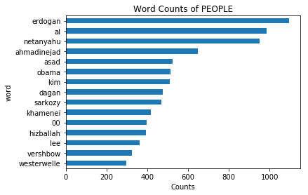

```python
people_pipe = make_pipe('PERSON')
people_counts = people_pipe.fit_transform(named_entities)
plot_counts(people_pipe.named_steps['vec'], people_counts, title='Word Counts of PEOPLE')
```

### The "Geo political" Entity

[figure not shown]

```python
geo_political_pipe = make_pipe('GPE')
geo_political_counts = geo_political_pipe.fit_transform(named_entities)
plot_counts(geo_political_pipe.named_steps['vec'], geo_political_counts, title="Word Counts of GEO POLITICAL ENTITIES")
```

### Now we can look at: which documents talk about:

1. **Person:** Obama,
2. **Verb:** help, and
3. **Geo-political Entity:** Iran?

```python
obama_help_iran_docs = set(np.where((people_counts[:, people_pipe.named_steps['vec'].vocabulary_['obama']] > 0).todense())[0]) & \
    set(np.where((verb_counts[:, verb_pipe.named_steps['vec'].vocabulary_['help']] > 0).todense())[0]) & \
    set(np.where((geo_political_counts[:, geo_political_pipe.named_steps['vec'].vocabulary_['iran']] > 0).todense())[0])
```

```python
"%d documents out of 1000" % len(obama_help_iran_docs)
```

```
'164 documents out of 1000'
```

#### example document

```python
records.iloc[list(obama_help_iran_docs)[0]][0][2000:5000]
```

```
' E C R E T SECTION 01 OF 04 TEL AVIV 002760  SIPDIS  TREASURY FOR LEVEY, S. ATHENS FOR PURCELL, A.  E.O. 12958: DECL: 12/10/2018 TAGS: KTFN EFIN ECON KWBG IR ISSUBJECT: U/S LEVEY REASSURES GOI THAT NO MOMENTUM WILL BE LOST IN THE FIGHT AGAINST TERROR FINANCE  Classified By: A/DCM Marc Sievers for r…
```

### cool!

**Uses of this technique in practice:**

Crawled 15,000 NYTimes articles published over the 2015-2016 election season.

https://www.nytimes.com/2016/11/04/insider/19-countries-43-states-327-cities-mapping-the-timess-election-coverage.html

[figure not shown]

```python
Image(filename='img/spangher_political_reporter_graphic.png', width=1000)
```

[figure not shown]

```python
Image(filename='img/contribline_example.png', width=600)
```

```python
displacy.render(nlp(u'Amy Chozick contributed reporting from Philadelphia, and Alan Rappeport from New York.'), style='ent', jupyter=True)
```

Amy Chozick PERSON contributed reporting from Philadelphia GPE , and Alan Rappeport PERSON from New York GPE .

**Another use case:**

Jennifer Golan and Shane Shifflet: *“Federal Judge’s Rulings Favored Companies in which He Owned Stock”*.

For this piece, the journalists **lists of companies owned by federal judges**.

1. Transcribed “statement of economic interest" disclosures to generate lists of companies in which judges owned stock.
2. Then, scraped the PACER database for every case those judges presided over
3. Used NER to generate a per-judge list of the entities involved.
4. By comparing these lists the reporters were able to find cases in which judges had ruled favorably for companies in which they owned stock.

https://www.publicintegrity.org/2014/04/28/14630/federal-judges-plead-guilty

# Approach #2: Look at the Topics

## Topic Modeling

Topic modeling extracts the topics that are present in a corpus.

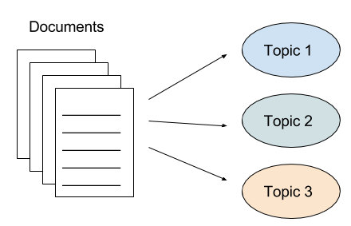

```python
Image('img/topic_modeling_visualization.png')
```

Each document in the corpus can then be described in terms of it's topic breakdown. Example:

- A corpus consists of two topics, **Art** and **Politics**.
- Then, documents in this corpus can be described as a combination these.

Here's an example of topic modeling in the context of NYTimes published in the summer of 2015.

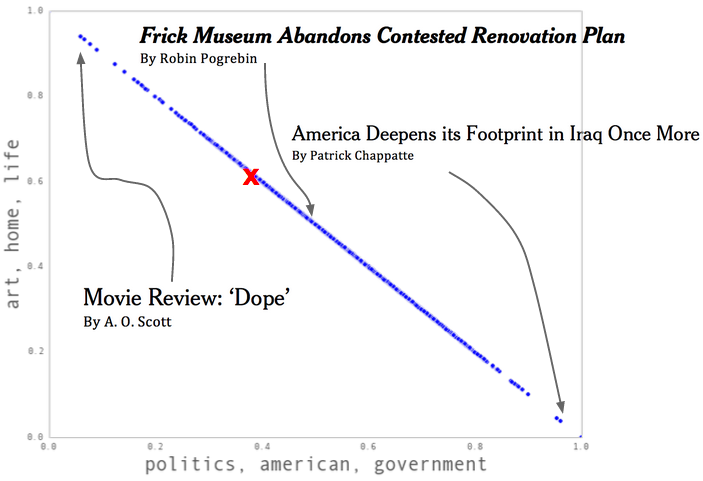

```python
Image('img/nytimes_example.png', width=600)
```

### What topics are cables mainly talking about?

```python
for topic_number, topic_words in enumerate([re.findall(r'[0-9A-Za-z ]*"([A-za-z]+)"[0-9A-Za-z ]*', topic) for i, topic in lda_model.show_topics(num_topics=45)]): print "topic # %d" % (topic_number + 1); print '   '.join([word for word in topic_words if 'xxxx' not in word]); print;
```

```
topic # 1
brazil   brasilia   brazilian   lula   cable   gob   said   amorim   ambassador   president

topic # 2
china   chinese   cable   said   africa   beijing   reference   new   also

topic # 3
afghanistan   would   nato   afghan   said   cable   kabul   karzai   security   also

topic # 4
uae   efforts   terrorist   security   iraq   including   plans   information   groups   us

topic # 5
pakistan   military   cable   egypt   zardari   security   government   general   islamabad   also

topic # 6
scottish   swiss   scotland   snp   muralt   hannibal   ambuhl   sweden   independence   salmond

topic # 7
russia   russian   cable   moscow   putin   french   political   would   us   france

topic # 8
lukashenko   sinai   ministry   minister   president   royg   minsk   university

topic # 9
bouteflika   portugal   algeria   portuguese   eta   morocco   said   welch   ringera   sahara

topic # 10
north   korea   would   missile   said   dprk   kosovo   defense   cable   states

topic # 11
cable   information   reference   new   also   please   security   government   specific   amembassy

topic # 12
ethanol   paulo   sao   serra   pt   lula   psdb   netto   delfim   gasoline

topic # 13
women   ipr   mexico   violence   gender   mexican   organizations   victims   protection   justice

topic # 14
```

[output cut: 64 more lines]

```

topic # 36
said   cable   israel   iran   would   turkey   also   israeli   president   reference

topic # 37
french   france   sarkozy   capt   cable   paris   cat   amembassy   air   also

topic # 38
cable   varig   rio   zelaya   brazilian   brazil   de   would   company   new

topic # 39
date   el   end   egypt   vetting   course   jahmi   dob   name   start

topic # 40
russia   russian   moscow   funes   gor   fmln   cooperation   russians   lavrov   cable
```

### let's look at documents in topic #18: [ gas oil bp company energy ]

#### Question #1: How many documents index highly for the oil/gas topic?

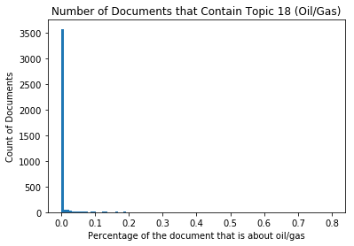

```python
theta_df['topic_18'].hist(bins=100)
plt.grid('off')
plt.title('Number of Documents that Contain Topic 18 (Oil/Gas)')
plt.ylabel('Count of Documents')
plt.xlabel('Percentage of the document that is about oil/gas');
```

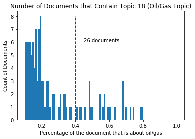

```python
theta_df['topic_18'].hist(bins=100, range=(.1, 1))
plt.grid('off')
plt.title('Number of Documents that Contain Topic 18 (Oil/Gas Topic)')
plt.ylabel('Count of Documents')
plt.xlabel('Percentage of the document that is about oil/gas')
plt.vlines(.4, 0, 8, linestyles='dashed')
plt.text(.45, 6, '%d documents' % (theta_df['topic_18'] > .4).sum());
```

#### Question #2: What are the top documents in this topic?

```python
for record in theta_df.sort_values('topic_18', ascending=False).head(3).text:
    print record[4000:7000]; print; print;
```

```
RO1050PP RUEHAG RUEHROVDE RUEHKB #0947/01 2821027ZNY CCCCC ZZHP 081027Z OCT 08FM AMEMBASSY BAKUTO RUEHC/SECSTATE WASHDC PRIORITY 0123INFO RUCNCIS/CIS COLLECTIVERUCNMEM/EU MEMBER STATESRHMFISS/CDR USEUCOM VAIHINGEN GERUEAIIA/CIA WASHINGTON DCRHEBAAA/DEPT OF ENERGY WASHDCRUEKDIA/DIA WASHDCRUEKJCS/JOIN…


ZCZCXRO9501PP RUEHAG RUEHDBU RUEHROVDE RUEHKB #0522/01 1171351ZNY CCCCC ZZHP 271351Z APR 07FM AMEMBASSY BAKUTO RUEHC/SECSTATE WASHDC PRIORITY 2916INFO RUCNCIS/CIS COLLECTIVE PRIORITYRUCNMEM/EU MEMBER STATES  PRIORITYRHMFISS/CDR USEUCOM VAIHINGEN GERUEAIIA/CIA WASHINGTON DCRHEBAAA/DEPT OF ENERGY WASH…


ble: a summary, a collection of specific topics and a comment section.To understand the justification used for the classification of each cable, please use this WikiSource article as reference.Discussing cablesIf you find meaningful or important information in a cable, please link directly to its un…
```

**Uses of this technique in practice:**

Joan Biskupic, Janet Roberts and John Shiffman, *“The Echo Chamber,”* (Reuters), wrote about about how a small group of elite lawyers have argued most of the cases before the U.S. Supreme Court.

- They assembled the 10,300 petitions to the court filed by over 17,000 lawyers from 2004 to 2012. Of these, only 528 cases were heard.
- **The reporters wanted to break down the number of accepted cases by type, for example whether filed by a business, individual, or government agency.**
- They applied topic modeling and after some experimentation found that 40 topics seemed to capture the structure of the petitions most clearly.
- **They examined the generated topics and manually labeled them with categories such as environmental regulation, congressional intent, utilities, etc.**

https://www.reuters.com/investigates/special-report/scotus/

Topic modeling for article recommendations:

https://open.blogs.nytimes.com/2015/08/11/building-the-next-new-york-times-recommendation-engine/

# Approach 3: “I’ll know it when I see it”

**Approach:**

1. Start labeling documents:
   1. "This is an example of what I **AM** looking for"
   2. "This is an example of what I'm **NOT** looking for"
2. Train a model with these examples

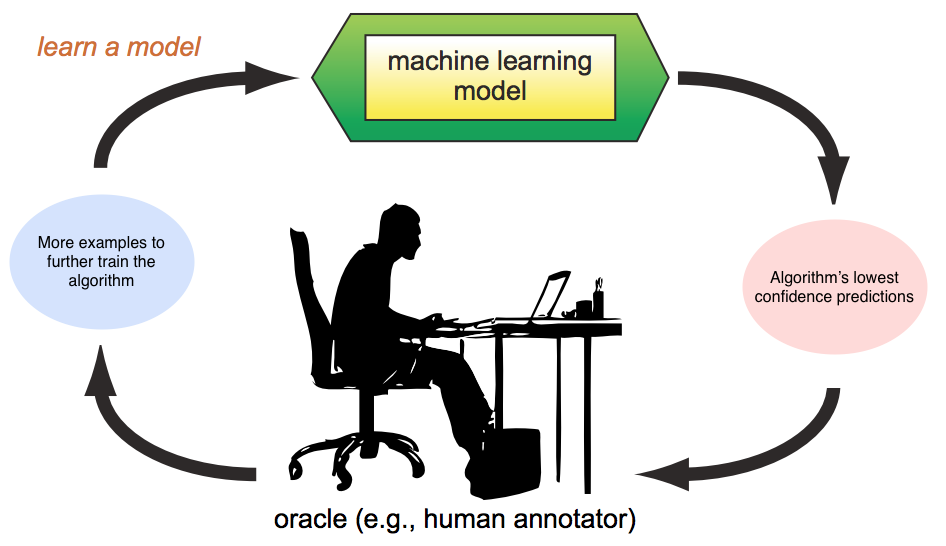

```python
Image("img/active_learning_example.png", width=600)
```

At each iteration, the algorithm asks you to label the hardest examples.

```python
df, pipe = setup_active_learning(records_slim); aucs = [];
for t in range(2): df, pipe, score = run_active_learning(df, pipe, batch_size=10); aucs.append(score);
```

```
...DushanbeEmbassy DublinEmbassy DohaEmbassy DjiboutiEmbassy DhakaEmbassy Dar Es SalaamEmbassy DamascusEmbassy DakarConsulate DubaiEmbassy FreetownEmbassy GuatemalaEmbassy GaboroneEmbassy HarareEmbassy HanoiConsulate HamburgIran RPO DubaiEmbassy IslamabadConsulate IstanbulEmbassy JakartaConsulate Je…
```

[output not shown]

### Accuracy over time

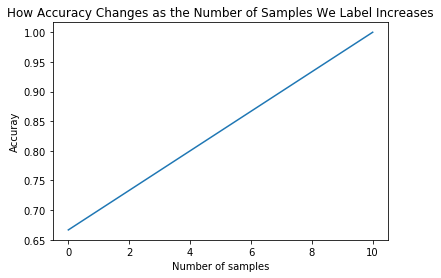

```python
plt.plot(np.arange(len(aucs)) * 10, aucs)
plt.ylabel('Accuray')
plt.xlabel("Number of samples")
plt.title('How Accuracy Changes as the Number of Samples We Label Increases');
```

#### We can now interrogate our model and ask: what *makes* something interesting?

```python
t = pipe.named_steps['model']
vec = pipe.named_steps['vec']
vocab = np.array(sorted(vec.vocabulary_.keys()))
list(vocab[np.argsort(-t.coef_[0,:])[:10]])
```

```
[u'german',
 u'berlin',
 u'unscr',
 u'shig',
 u'1747',
 u'computers',
 u'turkey',
 u'authorities',
 u'siemens',
 u'uav']
```

### now use this model to predict the most interesting piece that I haven't looked at yet, and show it to me

```python
df[df.class_label==1]
```

| index | text | y | max_p | class_label |
| --- | --- | --- | --- | --- |
| 2009/10/09ANKARA1472.html | 09ANKARA1472, SCENESETTER: YOUR VISIT TO TURK... | NaN | 0.603837 | 1.0 |
| 2009/11/09ANKARA1594.html | 09ANKARA1594, TURKISH MEDIA REACTIONIf you are... | NaN | 0.524122 | 1.0 |
| 2009/12/09ISTANBUL440.html | 09ISTANBUL440, TURKEY-IRAN RELATIONS: MOTIVATI... | NaN | 0.729873 | 1.0 |
| 2010/01/10ANKARA126.html | 10ANKARA126, SECRETARY GATES' TURKEY BILATERAL... | NaN | 0.687912 | 1.0 |
| 2010/01/10ANKARA87.html | 10ANKARA87, WHAT LIES BENEATH ANKARA'S NEW FOR... | NaN | 0.651136 | 1.0 |
| 2010/02/10ANKARA251.html | 10ANKARA251, SECRETARY OF DEFENSE GATES'S MEET... | NaN | 0.617061 | 1.0 |
| 2010/02/10USNATO52.html | CMGTDJEGEFINERELETRDETTCECONEINVEAGREUNEUENRGE... | NaN | 0.522916 | 1.0 |
| 2002/11/02ANKARA8305.html | DushanbeEmbassy DublinEmbassy DohaEmbassy Djib... | NaN | 0.611190 | 1.0 |
| 2006/06/06ANKARA3352.html | DushanbeEmbassy DublinEmbassy DohaEmbassy Djib... | NaN | 0.508832 | 1.0 |
| 2009/04/09BERLIN431.html | ColomboEmbassy ChisinauEmbassy CaracasEmbassy... | NaN | 0.617102 | 1.0 |

**Uses of this technique in practice:**

Carrie Teegardin, Danny Robbins, Jeff Ernsthausen and Ariel Hart, *“License to Betray”* (the Atlanta Journal Constitution).

Journalists reported on doctors who had sexually abused patients were allowed to continue practice. They drastically reduced this pile by **applying machine learning to identify reports that were likely to concern sexual abuse**.

- Reporters scraped over **100,000 doctor disciplinary records from every state**
- Manually labelled a few hundred documents to produce a training set
- Settled on logistic regression over a hand-selected set of relevant terms. (The final classifier had an accuracy of >0.9.)
- They trained a model and selected only those documents with a rated probability of 0.5 or greater of concerning sexual abuse **produced a set of 6,000 documents** which the reporters then read and coded manually.

http://doctors.ajc.com/doctors_sex_abuse/

**Newsroom tip classifier:**

- The NYTimes gets ~1,000 tips a day to a central database.
- Journalists "claim" tips by marking them **interesting** or **not**.
- Build a classifier to surface tips that are more likely to be interesting to journalists.

# Appendix

Other approaches in the field:

**Great paper**:

- Ways in which journalists have used these techniques previously: https://journalism.stanford.edu/cj2016/files/What%20do%20journalists%20do%20with%20documents.pdf

**Topic Modeling**

- Jonathan Stray: Using TF-IDF to create graphs in large document corpuses http://jonathanstray.com/a-full-text-visualization-of-the-iraq-war-logs
- Scientific paper: Machine Learning meets Data-Driven Journalism: Boosting International Understanding and Transparency in News Coverage: https://arxiv.org/pdf/1606.05110.pdf

**Active Learning**

- Active Learning for entity deduplication: http://cvs.cs.umd.edu/class/spring2012/cmsc828L/Papers/SarawagiKDD2002.pdf
- Same thing, but just a summary of a talk: https://odsc.com/training/portfolio/applying-active-learning-algorithm-entity-deduplication-graph-data
- Great Active Learning Literature Review: http://burrsettles.com/pub/settles.activelearning.pdf

**Other Machine Learning Techniques for journalism**

- Using auto-summarization for corpus research: http://www.storybench.org/how-machine-learning-could-change-journalism/
- http://datadrivenjournalism.net/news_and_analysis/machine_learning_and_data_journalism_can_support_democracy
- Toolkit for Automatic classification, slugline generation, trend detection, summarization, data gathering : https://www.iit.demokritos.gr/sites/default/files/a_multi-lingually_applicable_journalist_toolset_for_the_big-data_era_yds_july2016.pdf

**NLP/ML and Journalism Conferences:**

- 2017: http://nlpj2017.fbk.eu/accepted-papers
- 2016: http://nlpj2016.fbk.eu/accepted-papers

**Textbooks:**

- [The Data Journalism Handbook](https://www.amazon.com/Data-Journalism-Handbook-Journalists-Improve/dp/1449330061/)
- [Introduction to Information Retrieval](https://nlp.stanford.edu/IR-book/pdf/irbookonlinereading.pdf)